# Fatores associados à hospitalização por infecção

Welington Nogueira

# 🧩 Introdução

Este estudo tem como objetivo identificar fatores associados à hospitalização por infecção, com foco em variáveis demográficas, clínicas e comportamentais. A abordagem adotada é epidemiológica, utilizando regressão logística binária, com seleção progressiva de variáveis baseada em critério estatístico, parcimônia e coerência conceitual.

## Leitura dos Dados

```r
dados <- read.csv2(
"TABELA_FINAL_ANNA_07012022.csv",
fileEncoding = "Latin1",
stringsAsFactors = FALSE
)
```

## Padronização das variáveis

```r
dados <- dados %>%
janitor::clean_names() %>%
rename(
data_nascimento = nascimento,
raca_cor = cor_da_pele,
sintomas = teve_sintomas,
dor_garganta = dor_de_garganta,
falta_ar = falta_de_ar,
perda_olfato = perda_de_olfato,
perda_paladar = perda_do_paladar,
nauseas_vomitos = nauseas_e_vomitos,
dor_cabeca = dor_de_cabeca,
conjuntivite = conjutivite,
dor_articulacao = dores_nas_articulacoes,
perda_apetite = perda_do_apetite,
alteracoes_consciencia = alteracoes_de_consciencia,
hospitalizado = foi_hospitalizado,
doenca_coracao = doenca_do_coracao,
doenca_pulmonar = doenca_pulmonar_cronica,
doenca_figado = doenca_cronica_do_figado,
doenca_hematologica = doenca_hematologica_cronica,
doenca_reumatologica = doenca_reumatologica_cronica,
doenca_renal = doenca_renal_cronica,
outras_doencas = outra_doenca_cronica
)
```

## 🔹 Feature Engineering

Antes das análises estatísticas e da modelagem, foram realizadas etapas de feature engineering com o objetivo de tornar as variáveis mais interpretáveis, epidemiologicamente consistentes e estatisticamente estáveis.

A idade foi transformada em faixas etárias ordinalmente organizadas (≤39, 40–59 e ≥60 anos), permitindo captar possíveis efeitos não lineares do envelhecimento sobre o risco de hospitalização.

O índice de massa corporal (IMC) foi calculado a partir das medidas de peso e altura e posteriormente categorizado segundo critérios padronizados. Observou-se um número muito reduzido de indivíduos com baixo peso, o que poderia comprometer a estabilidade das estimativas. Por esse motivo, as categorias baixo peso e adequado foram agrupadas, resultando em três classes finais: Baixo/Adequado, Sobrepeso e Obesidade.

Essa estratégia reduz problemas de separação quase perfeita e melhora a robustez do modelo.

```r
dados <- dados %>%
mutate(
data_nascimento = dmy(data_nascimento),
idade = as.integer(interval(data_nascimento, Sys.Date()) / years(1)),
faixa_etaria = case_when(
idade <= 39 ~ "≤39",
idade <= 59 ~ "40–59",
idade >= 60 ~ "60+"
),
faixa_etaria = factor(faixa_etaria, levels = c("≤39","40–59","60+"))
)

# categorização do IMC

dados <- dados %>%
mutate(
peso = as.numeric(peso),
altura = as.numeric(altura),
imc = round(peso / (altura/100)^2, 1)
) %>%
filter(imc < 60) %>%
mutate(
imc_faixa = case_when(
imc < 18.5 ~ "Baixo peso",
imc < 25 ~ "Adequado",
imc < 30 ~ "Sobrepeso",
TRUE ~ "Obesidade"
),
imc_faixa = fct_collapse(
imc_faixa,
"Baixo/Adequado" = c("Baixo peso","Adequado"),
"Sobrepeso" = "Sobrepeso",
"Obesidade" = "Obesidade"
)
)
```

## 🔹 Padronização das variáveis binárias

As variáveis clínicas e demográficas originalmente codificadas como “Sim” e “Não” foram padronizadas para o formato binário (0/1). Essa transformação é essencial tanto para os testes de associação quanto para a regressão logística, garantindo coerência numérica e evitando ambiguidades durante a modelagem.

```r
binarias <- c(
"tabagista","sintomas","hospitalizado","diabetes",
"pressao_alta","doenca_coracao","doenca_pulmonar","doenca_renal"
)

dados <- dados %>%
mutate(across(all_of(binarias),
~ ifelse(.x=="Sim",1,ifelse(.x=="Não",0,NA))))
```

## 🔹 Análise exploratória

A análise exploratória inicial mostrou que aproximadamente 26,8% dos indivíduos foram hospitalizados, indicando um desfecho relativamente frequente na amostra analisada.

Esses achados justificam a inclusão dessas variáveis nas análises subsequentes.

```r
freq_eda <- function(var, binaria = FALSE){

  if(binaria){
    var <- factor(
      var,
      levels = c(0, 1),
      labels = c("Não", "Sim")
    )
  }

  tab <- table(var, useNA = "no")

  data.frame(
    Categoria        = names(tab),
    Frequencia       = as.numeric(tab),
    Percentual.Freq  = round(100 * as.numeric(prop.table(tab)), 1),
    row.names = NULL
  )
}

freq_eda(dados$hospitalizado, binaria = TRUE)
```

| Categoria | Frequencia | Percentual.Freq |
| --- | --- | --- |
| Não | 90 | 73.2 |
| Sim | 33 | 26.8 |

```r
freq_eda(dados$genero)
```

| Categoria | Frequencia | Percentual.Freq |
| --- | --- | --- |
| Homem | 58 | 46 |
| Mulher | 68 | 54 |

```r
freq_eda(dados$faixa_etaria)
```

| Categoria | Frequencia | Percentual.Freq |
| --- | --- | --- |
| ≤39 | 31 | 25.0 |
| 40–59 | 51 | 41.1 |
| 60+ | 42 | 33.9 |

```r
freq_eda(dados$imc_faixa)
```

| Categoria | Frequencia | Percentual.Freq |
| --- | --- | --- |
| Baixo/Adequado | 51 | 40.5 |
| Obesidade | 26 | 20.6 |
| Sobrepeso | 49 | 38.9 |

```r
freq_eda(dados$tabagista, binaria = TRUE)
```

| Categoria | Frequencia | Percentual.Freq |
| --- | --- | --- |
| Não | 88 | 69.8 |
| Sim | 38 | 30.2 |

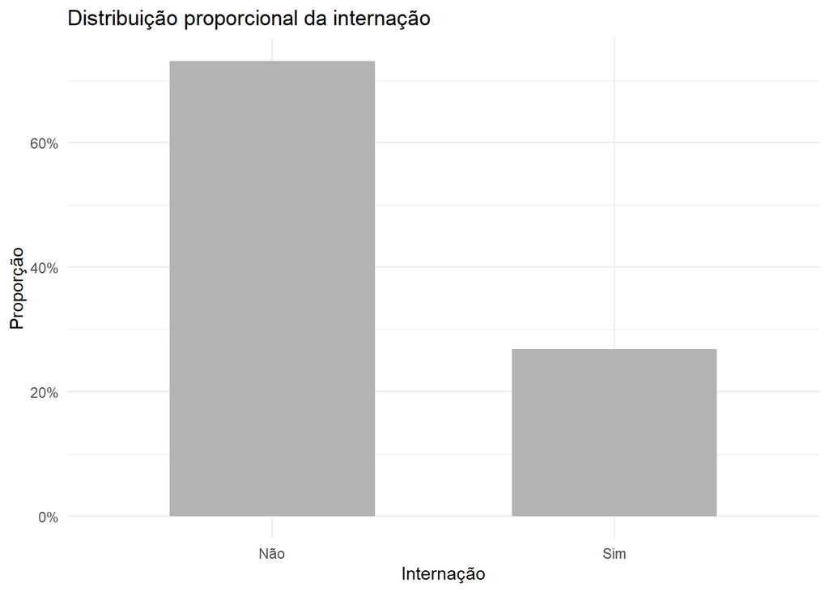

```r
#----
dados <- dados %>%
  mutate(
    hospitalizado = factor(
      hospitalizado,
      levels = c(0, 1),
      labels = c("Não", "Sim")
    )
  )
#----

ggplot(
  dados %>% filter(!is.na(hospitalizado)),
  aes(x = hospitalizado)
) +
  geom_bar(
    aes(y = after_stat(prop), group = 1),
    width = 0.6,
    fill = "grey70"
  ) +
  scale_y_continuous(labels = scales::percent) +
  labs(
    x = "Internação",
    y = "Proporção",
    title = "Distribuição proporcional da internação"
  ) +
  theme_minimal()
```

## 🔹 Distribuição da Internação

O gráfico de proporção evidencia visualmente que a internação não é um evento raro na amostra, reforçando a pertinência do uso da regressão logística como ferramenta analítica.

👤 Gênero

🎂 Faixa etária

Observa-se um gradiente etário claro:

≤39 anos: 6,5% de internação

40–59 anos: 28,6%

60 anos ou mais: 39,0%

Esse padrão evidencia aumento progressivo do risco de internação com o avanço da idade, destacando a população idosa como o grupo mais vulnerável.

⚖️ Índice de Massa Corporal (IMC)

As maiores proporções de internação foram observadas em:

Sobrepeso: 40,4%

Obesidade: 24,0%

Baixo/Adequado: 15,7%

Esses achados sugerem que o excesso de peso está associado a maior risco de internação, especialmente entre indivíduos com sobrepeso.

🚬 Tabagismo

Embora a proporção de internação tenha sido maior entre não tabagistas (30,2%) em comparação aos tabagistas (18,9%), essa diferença não foi estatisticamente significativa (p = 0,282; V de Cramer = 0,117).

O resultado deve ser interpretado com cautela, possivelmente refletindo características da amostra e não um efeito protetor do tabagismo.

🍬 Diabetes

Não houve associação estatisticamente significativa entre diabetes e internação (p = 0,848; V de Cramer = 0,048). A proporção de internação foi de 26,1% entre não diabéticos e 33,3% entre diabéticos, com ampla sobreposição entre os grupos.

❤️ Hipertensão arterial

A hipertensão apresentou maior proporção de internação (39,3%) em comparação aos não hipertensos (23,2%), porém sem significância estatística (p = 0,147), embora com efeito pequeno a moderado (V de Cramer = 0,153).

🫀 Doença cardíaca

Indivíduos com doença cardíaca apresentaram uma proporção de internação elevada (66,7%), frente a 24,8% entre aqueles sem a condição. Apesar do p-valor não atingir o nível convencional de significância (p = 0,074), o V de Cramer de 0,204 indica uma associação de magnitude relevante, possivelmente limitada pelo pequeno número de casos nesse grupo.

🫁 Doença pulmonar

A internação ocorreu em 50,0% dos indivíduos com doença pulmonar, contra 26,1% dos demais. Entretanto, essa diferença não foi estatisticamente significativa (p = 0,624; V de Cramer = 0,096), devendo ser interpretada com cautela devido ao baixo número de observações.

🧠 Doença renal

Entre indivíduos com doença renal, a proporção de internação foi de 40,0%, comparada a 26,3% entre aqueles sem a condição. Não houve associação estatisticamente significativa (p = 0,870; V de Cramer = 0,061), indicando efeito fraco nesta amostra.

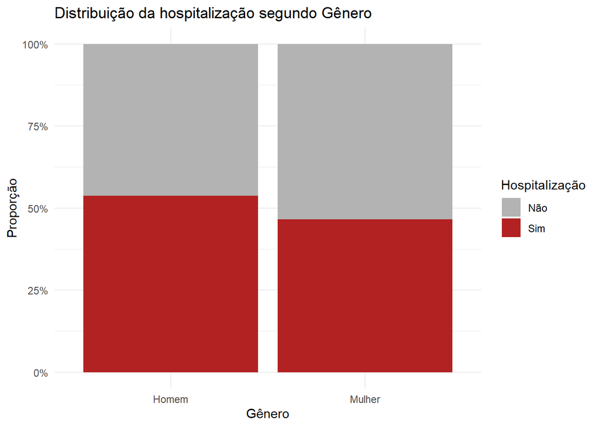

```r
plot_internacao <- function(var, nome_var){

  dados_plot <- dados %>%
    filter(
      !is.na(.data[[var]]),
      !is.na(hospitalizado)
    ) %>%
    mutate(
      var_plot = if (is.numeric(.data[[var]])) {
        factor(.data[[var]], levels = c(0, 1), labels = c("Não", "Sim"))
      } else {
        factor(.data[[var]])
      }
    )

  ggplot(
    dados_plot,
    aes(
      x = var_plot,
      fill = hospitalizado
    )
  ) +
    geom_bar(
      aes(y = after_stat(prop), group = hospitalizado),
      position = "fill"
    ) +
    scale_y_continuous(labels = scales::percent) +
    scale_fill_manual(
      values = c("Não" = "grey70", "Sim" = "firebrick"),
      name = "Hospitalização"
    ) +
    labs(
      x = nome_var,
      y = "Proporção",
      title = paste("Distribuição da hospitalização segundo", nome_var)
    ) +
    theme_minimal()
}

plot_internacao("genero", "Gênero")
```

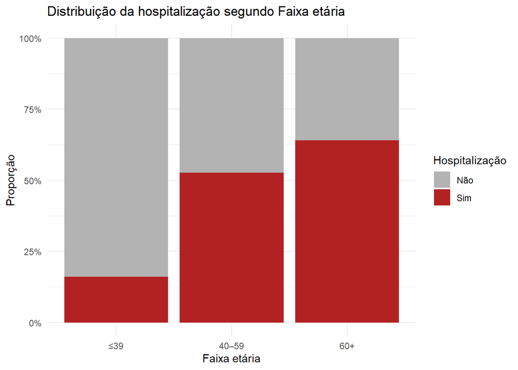

```r
plot_internacao("faixa_etaria", "Faixa etária")
```

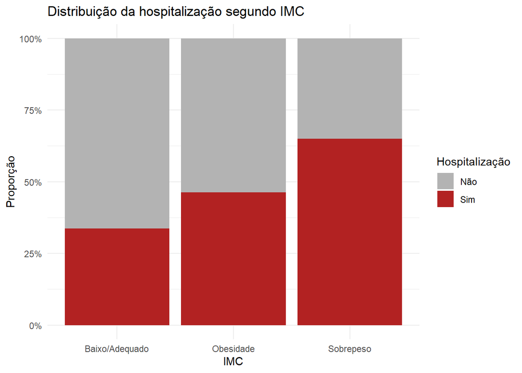

```r
plot_internacao("imc_faixa", "IMC")
```

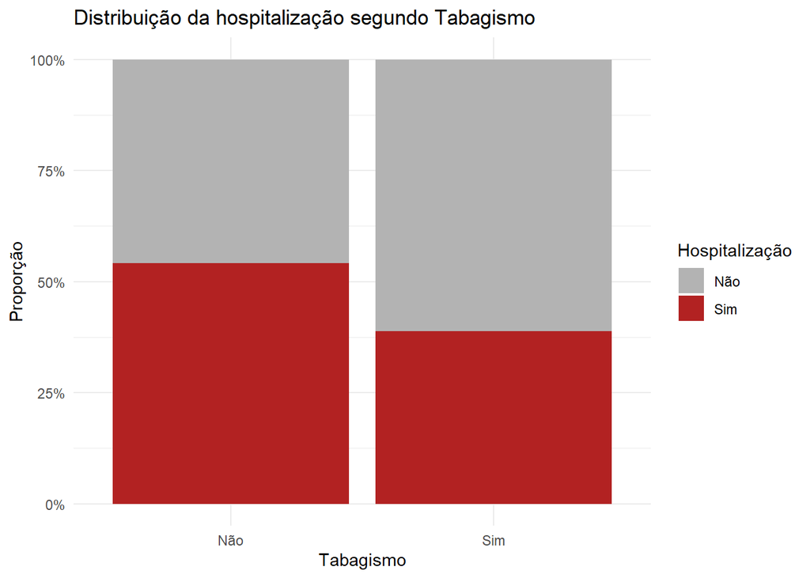

```r
plot_internacao("tabagista", "Tabagismo")
```

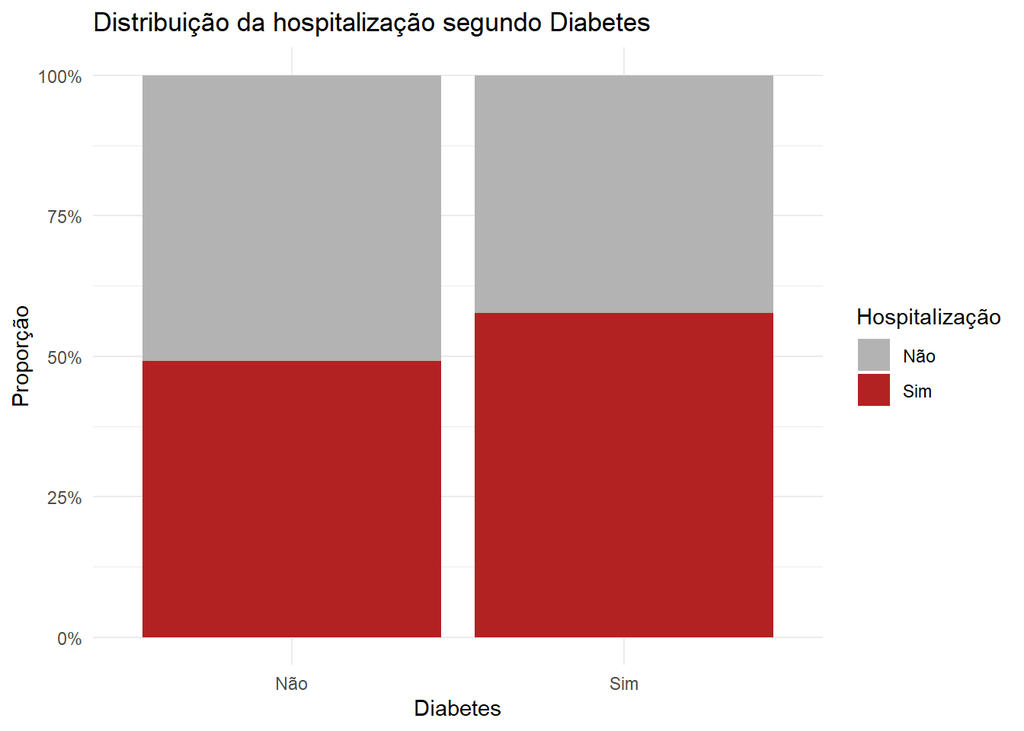

```r
plot_internacao("diabetes", "Diabetes")
```

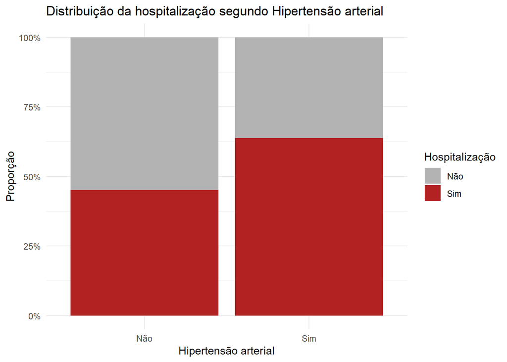

```r
plot_internacao("pressao_alta", "Hipertensão arterial")
```

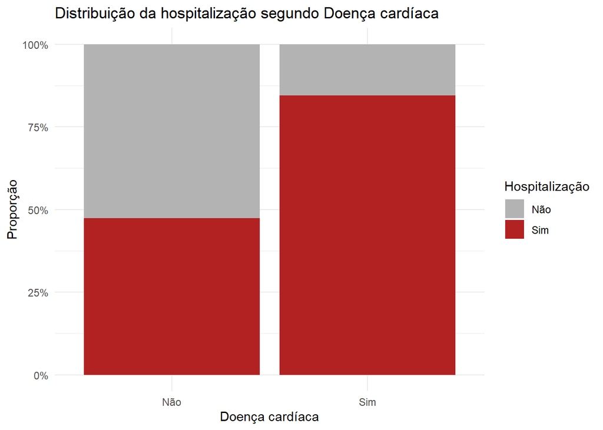

```r
plot_internacao("doenca_coracao", "Doença cardíaca")
```

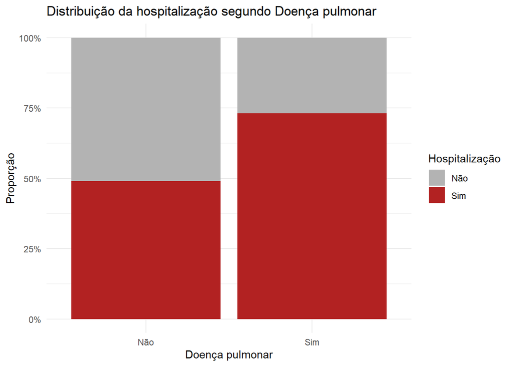

```r
plot_internacao("doenca_pulmonar", "Doença pulmonar")
```

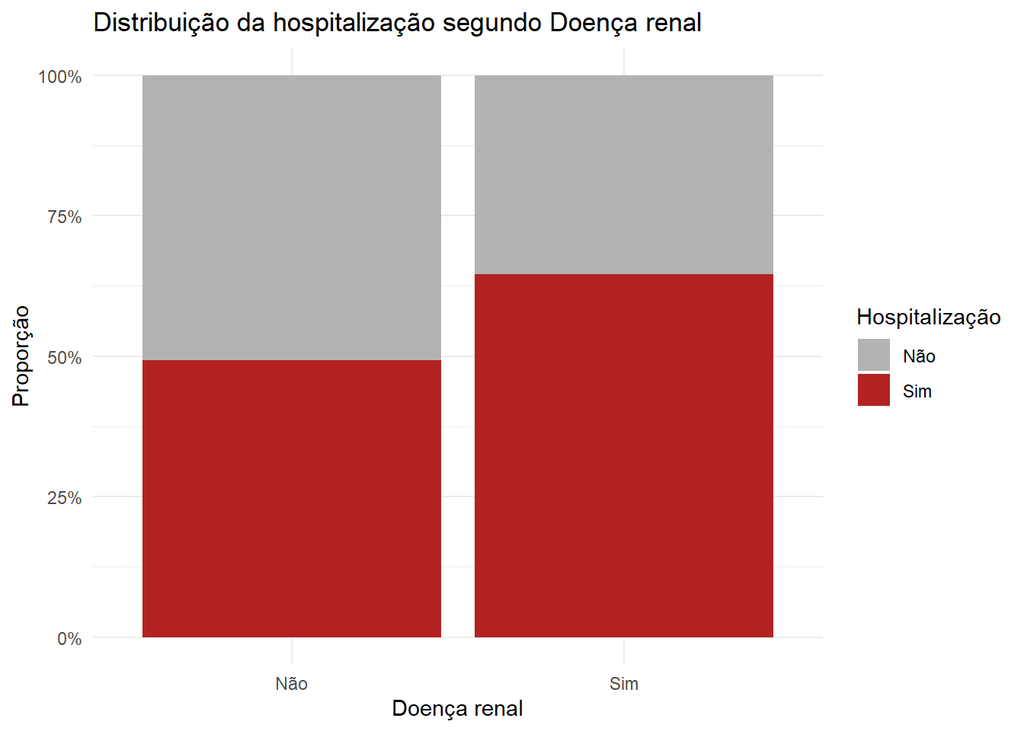

```r
plot_internacao("doenca_renal", "Doença renal")
```

## 🔹 Teste de Independência e V de Cramer

```r
vars <- c(
"genero","faixa_etaria","imc_faixa","tabagista",
"diabetes","pressao_alta","doenca_coracao",
"doenca_pulmonar","doenca_renal"
)

for(v in vars){
cat("\n###", v, "\n")
print(
knitr::kable(
descr::CrossTable(dados[[v]], dados$hospitalizado,
chisq = TRUE, prop.c = TRUE)$t,
caption = paste("Qui-quadrado –", v)
)
)
print(
knitr::kable(
data.frame(V_Cramer = rcompanion::cramerV(dados[[v]], dados$hospitalizado)),
caption = paste("V de Cramer –", v)
)
)
}
```

```
##
## ### genero
```

```
##
##
## Table: Qui-quadrado – genero
##
## |       | Não| Sim|
## |:------|---:|---:|
## |Homem  |  40|  17|
## |Mulher |  50|  16|
```

```
##
##
## Table: V de Cramer – genero
##
## |         | V_Cramer|
## |:--------|--------:|
## |Cramer V |  0.06207|
##
## ### faixa_etaria
```

```
##
##
## Table: Qui-quadrado – faixa_etaria
##
## |      | Não| Sim|
## |:-----|---:|---:|
## |≤39   |  29|   2|
## |40–59 |  35|  14|
## |60+   |  25|  16|
```

```
##
##
## Table: V de Cramer – faixa_etaria
##
## |         | V_Cramer|
## |:--------|--------:|
## |Cramer V |   0.1974|
##
## ### imc_faixa
```

```
##
##
## Table: Qui-quadrado – imc_faixa
##
## |               | Não| Sim|
## |:--------------|---:|---:|
## |Baixo/Adequado |  43|   8|
## |Obesidade      |  19|   6|
## |Sobrepeso      |  28|  19|
```

```
##
##
## Table: V de Cramer – imc_faixa
##
## |         | V_Cramer|
## |:--------|--------:|
## |Cramer V |   0.1754|
##
## ### tabagista
```

```
##
##
## Table: Qui-quadrado – tabagista
##
## |   | Não| Sim|
## |:--|---:|---:|
## |0  |  60|  26|
## |1  |  30|   7|
```

```
##
##
## Table: V de Cramer – tabagista
##
## |         | V_Cramer|
## |:--------|--------:|
## |Cramer V |   0.1157|
##
## ### diabetes
```

```
##
##
## Table: Qui-quadrado – diabetes
##
## |   | Não| Sim|
## |:--|---:|---:|
## |0  |  82|  29|
## |1  |   8|   4|
```

```
##
##
## Table: V de Cramer – diabetes
##
## |         | V_Cramer|
## |:--------|--------:|
## |Cramer V |  0.04769|
##
## ### pressao_alta
```

```
##
##
## Table: Qui-quadrado – pressao_alta
##
## |   | Não| Sim|
## |:--|---:|---:|
## |0  |  73|  22|
## |1  |  17|  11|
```

```
##
##
## Table: V de Cramer – pressao_alta
##
## |         | V_Cramer|
## |:--------|--------:|
## |Cramer V |   0.1508|
##
## ### doenca_coracao
```

```
##
##
## Table: Qui-quadrado – doenca_coracao
##
## |   | Não| Sim|
## |:--|---:|---:|
## |0  |  88|  29|
## |1  |   2|   4|
```

```
##
##
## Table: V de Cramer – doenca_coracao
##
## |         | V_Cramer|
## |:--------|--------:|
## |Cramer V |   0.2012|
##
## ### doenca_pulmonar
```

```
##
##
## Table: Qui-quadrado – doenca_pulmonar
##
## |   | Não| Sim|
## |:--|---:|---:|
## |0  |  88|  31|
## |1  |   2|   2|
```

```
##
##
## Table: V de Cramer – doenca_pulmonar
##
## |         | V_Cramer|
## |:--------|--------:|
## |Cramer V |  0.09473|
##
## ### doenca_renal
```

```
##
##
## Table: Qui-quadrado – doenca_renal
##
## |   | Não| Sim|
## |:--|---:|---:|
## |0  |  87|  31|
## |1  |   3|   2|
```

```
##
##
## Table: V de Cramer – doenca_renal
##
## |         | V_Cramer|
## |:--------|--------:|
## |Cramer V |  0.06046|
```

# 🔹 Modelo de Regressão Logística

A regressão logística foi construída de forma progressiva e comparativa, partindo de um modelo completo e avançando para modelos mais parcimoniosos. Essa abordagem permite avaliar o impacto da remoção de variáveis sobre o ajuste global e a interpretação epidemiológica.

```r
df_model <- dados %>%
  select(
    hospitalizado,
    genero,
    faixa_etaria,
    imc_faixa,
    tabagista,
    diabetes,
    pressao_alta,
    doenca_coracao,
    doenca_pulmonar,
    doenca_renal
  ) %>%
  na.omit()

# Garantir que hospitalizado é fator binário correto
df_model$hospitalizado <- factor(
  df_model$hospitalizado,
  levels = c("Não", "Sim")
)

# Divisão treino / teste / validação

set.seed(123)

idx <- createDataPartition(df_model$hospitalizado, p=0.7, list=FALSE)
treino <- df_model[idx,]
temp <- df_model[-idx,]

idx2 <- createDataPartition(temp$hospitalizado, p=0.5, list=FALSE)
teste <- temp[idx2,]
valid <- temp[-idx2,]
```

# 🔹 Modelo 1 (Completo)

```r
############################################################

# 15. MODELO 1 — REGRESSÃO LOGÍSTICA COMPLETA

############################################################

modelo_1 <- glm(
hospitalizado ~ genero + faixa_etaria + imc_faixa +
tabagista + diabetes + pressao_alta +
doenca_coracao + doenca_pulmonar + doenca_renal,
data = treino,
family = binomial
)

summary(modelo_1)
```

```
##
## Call:
## glm(formula = hospitalizado ~ genero + faixa_etaria + imc_faixa +
##     tabagista + diabetes + pressao_alta + doenca_coracao + doenca_pulmonar +
##     doenca_renal, family = binomial, data = treino)
##
## Coefficients:
##                    Estimate Std. Error z value Pr(>|z|)
## (Intercept)         -2.8795     0.9076  -3.173  0.00151 **
## generoMulher        -0.1807     0.5717  -0.316  0.75197
## faixa_etaria40–59    1.3435     0.9187   1.462  0.14365
## faixa_etaria60+      1.8382     0.9731   1.889  0.05889 .
## imc_faixaObesidade   0.9091     0.8503   1.069  0.28500
## imc_faixaSobrepeso   1.3175     0.7315   1.801  0.07170 .
## tabagista           -0.8328     0.6433  -1.295  0.19543
## diabetes            -0.7490     0.9979  -0.751  0.45291
## pressao_alta        -0.1946     0.6805  -0.286  0.77491
## doenca_coracao       1.4164     1.0437   1.357  0.17475
## doenca_pulmonar      1.7301     1.2172   1.421  0.15521
## doenca_renal         0.6411     1.1004   0.583  0.56013
## ---
## Signif. codes:  0 '***' 0.001 '**' 0.01 '*' 0.05 '.' 0.1 ' ' 1
##
## (Dispersion parameter for binomial family taken to be 1)
##
##     Null deviance: 99.880  on 85  degrees of freedom
## Residual deviance: 81.476  on 74  degrees of freedom
## AIC: 105.48
##
## Number of Fisher Scoring iterations: 5
```

### AIC e Pseudo R²

```r
# AIC e Pseudo-R²

aic_1 <- AIC(modelo_1)
r2_1  <- 1 - modelo_1$deviance / modelo_1$null.deviance

data.frame(
Modelo = "Modelo 1 – Completo",
AIC = aic_1,
McFadden_R2 = r2_1
)
```

| Modelo | AIC | McFadden_R2 |
| --- | --- | --- |
| Modelo 1 – Completo | 105.4761 | 0.1842607 |

### Odds Ratio e IC

```r
# Odds Ratio e IC

OR_1 <- exp(coef(modelo_1))
IC_1 <- exp(confint(modelo_1))

data.frame(
Variavel = names(OR_1),
OR = round(OR_1, 3),
IC_Inf = round(IC_1[,1], 3),
IC_Sup = round(IC_1[,2], 3)
)
```

|  | Variavel | OR | IC_Inf | IC_Sup |
| --- | --- | --- | --- | --- |
| (Intercept) | (Intercept) | 0.056 | 0.007 | 0.267 |
| generoMulher | generoMulher | 0.835 | 0.270 | 2.601 |
| faixa_etaria40–59 | faixa_etaria40–59 | 3.832 | 0.716 | 30.461 |
| faixa_etaria60+ | faixa_etaria60+ | 6.285 | 1.049 | 54.486 |
| imc_faixaObesidade | imc_faixaObesidade | 2.482 | 0.476 | 14.206 |
| imc_faixaSobrepeso | imc_faixaSobrepeso | 3.734 | 0.943 | 17.583 |
| tabagista | tabagista | 0.435 | 0.111 | 1.448 |
| diabetes | diabetes | 0.473 | 0.053 | 3.090 |
| pressao_alta | pressao_alta | 0.823 | 0.203 | 3.062 |
| doenca_coracao | doenca_coracao | 4.122 | 0.559 | 39.395 |

[output cut: 2 more lines]

### Curva ROC

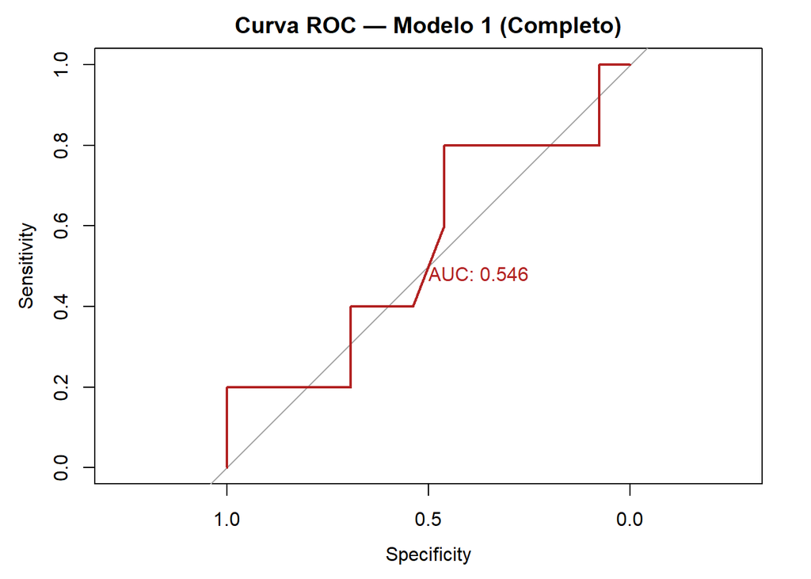

```r
# Curva ROC

teste$prob_1 <- predict(modelo_1, newdata = teste, type = "response")
roc_1 <- roc(teste$hospitalizado, teste$prob_1)

plot(
roc_1,
print.auc = TRUE,
col = "firebrick",
main = "Curva ROC — Modelo 1 (Completo)"
)
```